# Negativas de acesso a informação no governo Federal

```r
library(tidyverse)
library(lubridate)
library(glue)
library(here)
library(ggtext)
library(patchwork)

set.seed(1014)

knitr::knit_hooks$set(inline = function(x) prettyNum(x, big.mark = ".", decimal.mark = ","))

options(digits = 1,
        scipen = 999,
        OutDec = ",",
        knitr.kable.NA = '')

Sys.setenv(LANGUAGE = "pt-br")
Sys.setlocale("LC_TIME", "pt_BR")
```

```
#> [1] ""
```

```r
# aplica identidade visual da TB/AeP
aep_colors <- c(

  laranja = "#F9A521",
  rosa = "#D81755",
  cinza = "#969696",
  marrom = "#B27D5C"

)

paleta_governo = c(

  `Dilma II` = aep_colors[["laranja"]],
  `Temer` = aep_colors[["cinza"]],
  `Bolsonaro` = aep_colors[["rosa"]]

)

tb_colors <- c(

  laranja = "#F6A323",
  cinza_escuro = "#1d1d1b",
  cinza_claro =  "#6f7171",
  cinza_quase_branco = "#ececec",
  azul = "#41ACBD"

  )
```

```r
pedidos_cgu <- readRDS(here("dados/load/rds/pedidos-cgu.rds")) %>%
  mutate(across(starts_with("ts_"), ~ dmy(.x))) %>%
  filter(data_registro < as_date("2021-06-01"),
         data_resposta < as_date("2021-06-01"))

recursos_cgu <- readRDS(here("dados/load/rds/recursos-cgu.rds"))
```

## Introdução

O objetivo deste relatório é apresentar uma avaliação a respeito das negativas de acesso aos pedidos de informação feitos para os órgãos e entidades do poder Executivo federal via [LAI](http://www.planalto.gov.br/ccivil_03/_ato2011-2014/2011/lei/l12527.htm) e registrados no [portal da Acesso a Informação do Governo Federal](http://www.consultaesic.cgu.gov.br/busca/SitePages/Principal.aspx).

As negativas de acesso a informação foram analisadas considerando as classificações de atendimento que os próprios órgãos do Governo Federal atribuem aos pedidos de informação que recebem. As classificações de pedidos de informação utilizadas pelo Governo Federal são:

- Acesso concedido: fornecimento da informação demandada.
- Acesso parcialmente concedido: fornecimento de parte da informação demandada e negativa ou não atendimento de parte do pedido.
- Acesso negado: negativa de fornecimento da informação demandada.
- Informação inexistente.
- Não se trata de solicitação de informação.
- Órgão não tem competência para responder sobre o assunto.
- Pergunta Duplicada/Repetida.

Além das classificações de atendimento, a Controladoria Geral da União atribui uma especificação que justifica a decisão sobre o pedido de informação encaminhado aos órgãos do Executivo. Neste relatório, foram consideradas somente as especificações atribuídas aos pedidos com acesso negado (tabela completa em anexo), sendo elas:

- Pedido incompreensível
- Processo decisório em curso
- Informação sigilosa classificada conforme a Lei 12.527/2011
- Informação sigilosa de acordo com legislação específica
- Pedido exige tratamento adicional de dados
- Dados pessoais
- Pedido desproporcional ou desarrazoado
- Pedido genérico

A análise cobre o período de 01/01/2015 até 31/05/2021, abrangendo o final do segundo mandato de Dilma Rousseff (até meados de maio de 2016), todo o mandato de Michel Temer (de meados de maio de 2016 até dezembro de 2018) e o mandato de Jair Bolsonaro (de janeiro de 2019 até maio de 2021). Especificamente, foram analisados os seguintes aspectos:

- A frequência total de pedidos de acesso a informação e a proporção de respostas atendidas (classificadas como “acesso concedido”) ano a ano, categorizando o período analisado por governo.
- A frequência das classificações de atendimento atribuídas pelos órgãos, categorizadas por governo.
- A prevalência de termos considerados controversos no texto das respostas de “Acesso negado”, a saber: “Trabalho adicional”, “Fishing”, “Desproporcional”, “Desarrazoado”, “Dados sigilosos”, “Dados pessoais”, “Pedido genérico”, “Processo decisório em curso” e “Segurança Nacional” e “Lei Geral de Proteção de Dados”
- A evolução das negativas de pedidos de acesso a informação no contexto da nova [Lei Geral de Proteção de Dados](http://www.planalto.gov.br/ccivil_03/_ato2015-2018/2018/lei/l13709.htm).

É importante ressaltar que este relatório não considera possíveis distorções que as classificações supracitadas estão sujeitas no que tange ao mérito da resposta fornecida pelos órgãos do Executivo federal. Em [estudos anteriores](https://www.transparencia.org.br/downloads/publicacoes/Alteracoes_atendimento_pedidos_de_informacao_e_MP_928.pdf), foram detectadas inconsistências entre a classificação da resposta atribuída por um órgão e a real qualidade dessa resposta em relação ao que foi objetivamente solicitado pelo requerente do pedido, demonstrando casos onde o órgão considerou o acesso concedido quando a real resposta ao pedido foi uma negativa.

Os dados de utilizados neste relatório foram coletados do [e-sic do Governo Federal](http://www.consultaesic.cgu.gov.br/busca/_layouts/15/DownloadPedidos/DownloadDados.aspx). A coleta, tratamento e análise dos dados está documentada para fins de reproducibilidade no [GitHub da Transparência Brasil](https://github.com/Transparencia-Brasil/negativas-acesso-informacao-Executivo-federal-2021-1).

Os resultados da análise são destacados a seguir:

## Dados de pedidos de acesso a informação via LAI

A Controladoria Geral da União, através do [portal da Acesso a Informação do Governo Federal](http://www.consultaesic.cgu.gov.br/busca/SitePages/Principal.aspx) disponibiliza os dados de solicitações de acesso a informação realidas aos órgãos públicos do poder Executivo federal.

Em maio de 2021 a base registrava 579.352 pedidos armazenados com repostas para 305 órgãos e entidades do poder Executivo federal.

#### Pedidos de acesso a informação - quantidades de registros mês a mês

##### Poder executivo

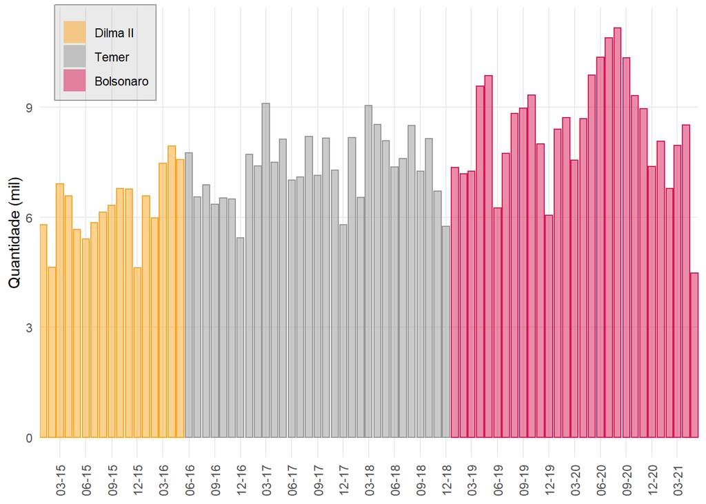

```r
pedidos_por_mes <- pedidos_cgu %>%
  group_by(data_registro, governo_que_registrou) %>%
  summarise(qt = n(), .groups = "drop")

pedidos_por_mes %>%
  ggplot() +
  geom_bar(
    aes(x = data_registro, y = qt / 1e3, fill = governo_que_registrou, color = governo_que_registrou),
    stat = "identity",
    alpha = .5
  ) +
  theme_minimal() +
  scale_fill_manual(values = paleta_governo) +
  scale_color_manual(values = paleta_governo) +
  scale_x_date(breaks = scales::date_breaks("3 months"), date_labels = "%m-%y", expand = c(0,0)) +
  labs(
    y = "Quantidade (mil)",
    x = NULL,
    fill = NULL,
    title = NULL,
    subtitle = NULL
  ) +
  theme(
    axis.text.x = element_text(hjust = .5, vjust = .5, angle = 90),
    legend.position = c(.1, .9),
    panel.grid.minor = element_blank(),
    legend.background = element_rect(fill = alpha(aep_colors[["cinza"]], .2), color = aep_colors[["cinza"]])
  ) +
  guides(color = FALSE)
```

## Acessos concedidos

```r
# Quantidades de pedidos, em milhares
pedidos_mesmo_periodo <- pedidos_cgu %>%
  select(data_registro, id_pedido) %>%
  filter(month(data_registro) < 5) %>%
  mutate(data_registro = floor_date(data_registro, unit = "year")) %>%
  group_by(data_registro) %>%
  summarise(qt = n() / 1e3, .groups = "drop") %>%
  mutate(data_registro = ordered(year(data_registro)))

# Acessos concedidos
acessos_concedidos_mesmo_periodo <- pedidos_cgu %>%
  filter(decisao == "Acesso Concedido") %>%
  select(data_registro, id_pedido) %>%
  filter(month(data_registro) < 5) %>%
  mutate(data_registro = floor_date(data_registro, unit = "year")) %>%
  group_by(data_registro) %>%
  summarise(qt = n() / 1e3, .groups = "drop") %>%
  mutate(data_registro = ordered(year(data_registro)))

# Índices de acessos concedidos
indice_respostas_concedidas <- pedidos_mesmo_periodo %>%
  left_join(acessos_concedidos_mesmo_periodo, by = "data_registro", suffix = c("_pedidos", "_concedidos")) %>%
  mutate(indice_acessos_concedidos = qt_concedidos / qt_pedidos)
```

#### Atendimento da LAI ano a ano - 2015 a 2021

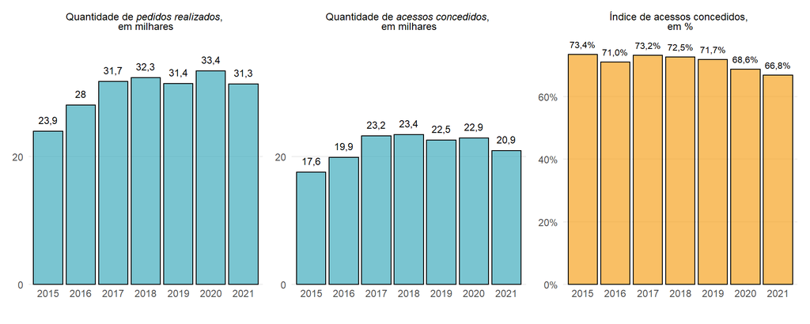

```r
# A quantidade de pedidos aumentou...
p1 <- pedidos_mesmo_periodo %>%
  ggplot() +
  geom_bar(aes(x = data_registro, y = qt), stat = "identity", fill = tb_colors[["azul"]],
           alpha = .7, color = "black") +
  labs(
    x = NULL,
    y = NULL,
    title = "Quantidade de *pedidos realizados*, <br> em milhares"
  ) +
  geom_text(aes(x = data_registro, y = qt, label = round(qt, 1)), vjust = -1, size = 3) +
  theme_minimal() +
  theme(
    plot.title = element_markdown(vjust = .5, hjust = .5, size = 9),
    plot.subtitle = element_markdown(vjust = .5, hjust = .5),
    panel.grid.minor = element_blank(),
    panel.grid.major.x = element_blank(),
    axis.text.x = element_text(vjust = 7)
  )  +
  scale_y_continuous(breaks = seq(0, 65, 20), limits = c(0, max(pedidos_mesmo_periodo$qt) * 1.1))

#...mas a quantidade de acessos continuou estável...
p2 <- acessos_concedidos_mesmo_periodo %>%
  ggplot() +
  geom_bar(aes(x = data_registro, y = qt), stat = "identity", fill = tb_colors[["azul"]],
           alpha = .7, color = "black") +
  labs(
    x = NULL,
    y = NULL,
    title = "Quantidade de *acessos concedidos*, <br>em milhares"
  ) +
  geom_text(aes(x = data_registro, y = qt, label = round(qt, 1)),
            vjust = -1, size = 3) +
  theme_minimal() +
  theme(
    plot.title = element_markdown(vjust = .5, hjust = .5, size = 9),
    plot.subtitle = element_markdown(vjust = .5, hjust = .5),
    panel.grid.minor = element_blank(),
    panel.grid.major.x = element_blank(),
    axis.text.x = element_text(vjust = 7)
  )  +
  scale_y_continuous(breaks = seq(0, 65, 20), limits = c(0, max(pedidos_mesmo_periodo$qt) * 1.1))

#...como consequência, a taxa de acessos concedidos caiu.
p3 <- indice_respostas_concedidas %>%
  ggplot() +
  geom_bar(aes(x = data_registro, y = indice_acessos_concedidos), fill = tb_colors[["laranja"]],
           stat = "identity", alpha = .7, color = "black") +
  geom_text(aes(x = data_registro, y = indice_acessos_concedidos,
                label = scales::percent(indice_acessos_concedidos, accuracy = 0.1, decimal.mark = ",")),
            vjust = -1, size = 2.8) +
  scale_y_continuous(labels = scales::percent_format(), limits = c(0, .75)) +
  labs(
    x = NULL,
    y = NULL,
    title = "Índice de acessos concedidos, <br>em %"
  ) +
  theme_minimal() +
  theme(
    plot.title = element_markdown(vjust = .5, hjust = .5, size = 9),
    plot.subtitle = element_markdown(vjust = .5, hjust = .5),
    panel.grid.minor = element_blank(),
    panel.grid.major.x = element_blank(),
    axis.text.x = element_text(vjust = 7)
  )

p1 + p2 + p3
```

O índice de acessos concedidos aos pedidos de informação é o percentual de pedidos em que o Governo Federal concede acesso ao requerente em relação ao total de pedidos registrados no e-sic do Governo Federal. Além de “acesso concedido”, o Governo Federal classifica as respostas aos pedidos de informação via LAI como “Não se trata de solicitação de informação”, “Acesso negado”, “Acesso parcialmente concedido”, “Informação inexistente”, “Órgão não tem competência para responder sobre o assunto”, “Pergunta duplicada/repetida”.

```r
# tipo respostas mais comuns histórico -----------------------------------------
respostas_comuns <- pedidos_cgu %>%
  group_by(data_resposta, decisao, governo_que_respondeu) %>%
  summarise(qt = n(), .groups = "drop") %>%
  mutate(
    decisao = case_when(
      decisao == "Órgão não tem competência para responder sobre o assunto" ~
        "Órgão não tem competência \npara responder sobre o assunto",
      TRUE ~ decisao
      ) %>% fct_reorder(qt, .desc = T)
    )

# respostas total por governo --------------------------------------------------
aux <- respostas_comuns %>%
  group_by(governo_que_respondeu) %>%
  summarise(qt = sum(qt), .groups = "drop") %>%
  ungroup()

# finaliza rcom taxa de tipo/total de respostas --------------------------------
respostas_comuns_gov <- respostas_comuns %>%
  group_by(governo_que_respondeu, decisao) %>%
  summarise(qt = sum(qt), .groups = "drop") %>%
  left_join(aux, by = "governo_que_respondeu", suffix = c("_tipo_resposta", "_respostas_total")) %>%
  mutate(perc = qt_tipo_resposta / qt_respostas_total)
```

#### Respostas mais comuns entre os governos

##### Frequência das classificações de atendimento atribuídas pelos órgãos do Executivo federal - por mês e por governo

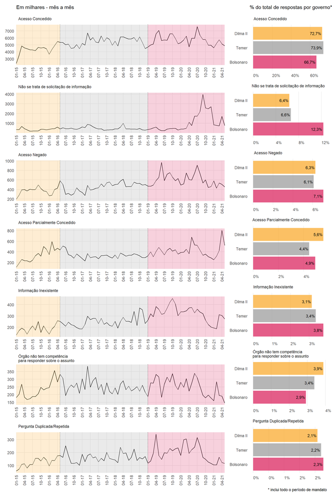

```r
# cores de fundo ---------------------------------------------------------------
periodo_final <- "2021-05-01"
rect_gov <- tibble(
  governo_que_respondeu = c("Dilma II", "Temer", "Bolsonaro"),
  xmin = c("2015-01-01",
           "2016-05-01",
           "2019-01-01"), # inicio de cada governo
  xmax = lead(xmin, default = periodo_final), # fim de cada governo
  ymin = -Inf,
  ymax = Inf
) %>% mutate(across(xmin:xmax, ~ as_date(ymd(.x))))

# plot esquerdo ----------------------------------------------------------------
p1 <- respostas_comuns %>%
  ggplot() +
  geom_line(aes(x = data_resposta, y = qt), show.legend = F) +
  geom_vline(xintercept = ymd(c("2016-05-01", "2019-01-01")), lty = 3) +
  geom_rect(
    data = rect_gov,
    aes(xmin = xmin, xmax = xmax, ymin = ymin, ymax = ymax, fill = governo_que_respondeu),
    alpha = .2, show.legend = F
  ) +
  scale_fill_manual(values = paleta_governo) +
  scale_color_manual(values = paleta_governo) +
  theme_minimal() +
  theme(
    legend.position = "top",
    legend.text = element_text(size = 8),
    axis.text.x = element_text(hjust = .5, vjust = .5, angle = 90),
    panel.grid.minor = element_blank(),
    strip.text = element_text(angle = 0, hjust = 0)
  ) +
  scale_x_date(breaks = scales::date_breaks("3 months"), date_labels = "%m-%y", expand = c(0, 0)) +
  labs(
    x = NULL,
    y = NULL,
    subtitle = "Em milhares - mês a mês",
    color = NULL,
    fill = NULL
  ) +
  facet_wrap(~ reorder(decisao, -qt), scales = 'free', ncol = 1)

# plot direito -----------------------------------------------------------------
p2 <- respostas_comuns_gov %>%
  ggplot(aes(x = fct_rev(governo_que_respondeu), y = perc, fill = governo_que_respondeu)) +
  geom_col(alpha = .7) +
  geom_text(aes(label = scales::percent(perc, accuracy = 0.1, decimal.mark = ",")),
            size = 3, hjust = 1.1, check_overlap = T) +
  scale_y_continuous(labels = scales::percent_format(accuracy = 1, decimal.mark = ","))   +
  coord_flip() +
  labs(
    x = NULL,
    y = NULL,
    fill = NULL,
    subtitle = "% do total de respostas por governo*",
    caption = "* inclui todo o período de mandato"
  ) +
  theme_minimal() +
  scale_fill_manual(values = paleta_governo) +
  scale_color_manual(values = paleta_governo) +
  theme(
    plot.subtitle = element_text(),
    panel.grid.major.y = element_blank(),
    panel.grid.minor.x = element_blank(),
    strip.text = element_text(angle = 0, hjust = .05),
    axis.text.x = element_text(hjust = 0, vjust = 0)
  ) +
  facet_wrap(~ reorder(decisao, -qt_tipo_resposta), scales = 'free', ncol = 1)

comb <- p1 + p2 & theme(legend.position = "none")
comb + plot_layout(widths = c(2.7, 1))
```

## Acesso negado

```r
# termos controversos ----------------------------------------------------------
termos_controversos <- c(
  'desarrazoado',
  'fishing',
  'desproporciona[l|is]',
  'seguranca nacional',
  'seguranca do estado',
  'sigilo',
  'processo decisorio em curso',
  'documento preparatorio',
  'trabalho[s]? adiciona',
  'dado[s]? pesso',
  'generico',
  'lgpd',
  'lei geral de proteção de dados pessoais',
  '13\\.?709',
  '13\\.?853'
  ) %>%
  paste0(collapse = "|")

# Total de acessos negados por mês----------------------------------------------
aux_mes <- pedidos_cgu %>%
  filter(decisao == "Acesso Negado") %>%
  group_by(data_resposta) %>%
  summarise(total_acessos_negados_mes = n(), .groups = "drop")

# Total de acessos negados por dia----------------------------------------------
aux_dia <- pedidos_cgu %>%
  filter(decisao == "Acesso Negado") %>%
  group_by(ts_resposta) %>%
  summarise(total_acessos_negados_dia = n(), .groups = "drop")

# Total de acessos negados por governo------------------------------------------
aux_gov <- pedidos_cgu %>%
  filter(decisao == "Acesso Negado") %>%
  group_by(governo_que_respondeu) %>%
  summarise(total_acessos_negados_gov = n(), .groups = "drop")

# tbl com termos controversos --------------------------------------------------
controversos <- pedidos_cgu %>%
  filter(decisao == "Acesso Negado") %>%
  select(data_resposta,
         ts_resposta,
         decisao,
         resposta,
         governo_que_respondeu,
         id_pedido) %>%
  # processamento de texto:
  mutate(resposta = tolower(resposta),
         resposta = str_squish(resposta),
         resposta = stringi::stri_trans_general(resposta, "Latin-ASCII")) %>%
  filter(str_detect(resposta, termos_controversos)) %>%
  mutate(
    controversos_desarrazoado = str_detect(resposta,'desarrazoado'),
    controversos_fishing  = str_detect(resposta,'fishing'),
    controversos_desproporcional =  str_detect(resposta,'desproporciona[l|is]'),
    controversos_seguranca =  str_detect(resposta,'segurança [nacional|do estado]'),
    controversos_sigilo = str_detect(resposta,'sigilo'),
    controversos_decisao =  str_detect(resposta,'processo decisorio em curso|documento preparatorio'),
    controversos_trabalho_adic = str_detect(resposta,'trabalho[s]? adiciona'),
    controversos_dados_pessoais =  str_detect(resposta,'dado[s]? pesso'),
    controversos_generico =  str_detect(resposta,'generico'),
    controversos_lgpd = str_detect(resposta, 'lei geral de proteção de dados|lei de protecao de dados pessoais|13\\.?709|13\\.?853|lgpd'),
    ) %>%
  inner_join(aux_mes, by = "data_resposta") %>%          # acesso negado/mês
  inner_join(aux_dia, by = "ts_resposta") %>%
  inner_join(aux_gov, by = "governo_que_respondeu") %>%  # acesso negado/governo
  pivot_longer(names_to = "controversos", cols = starts_with("controversos"),
               values_to = "prevalencia", names_prefix = "controversos_")
```

#### Especificação das decisões de acesso negado

##### Percentual da justificativa nos pedidos com acesso negados - comparação entre os governos (período completo)

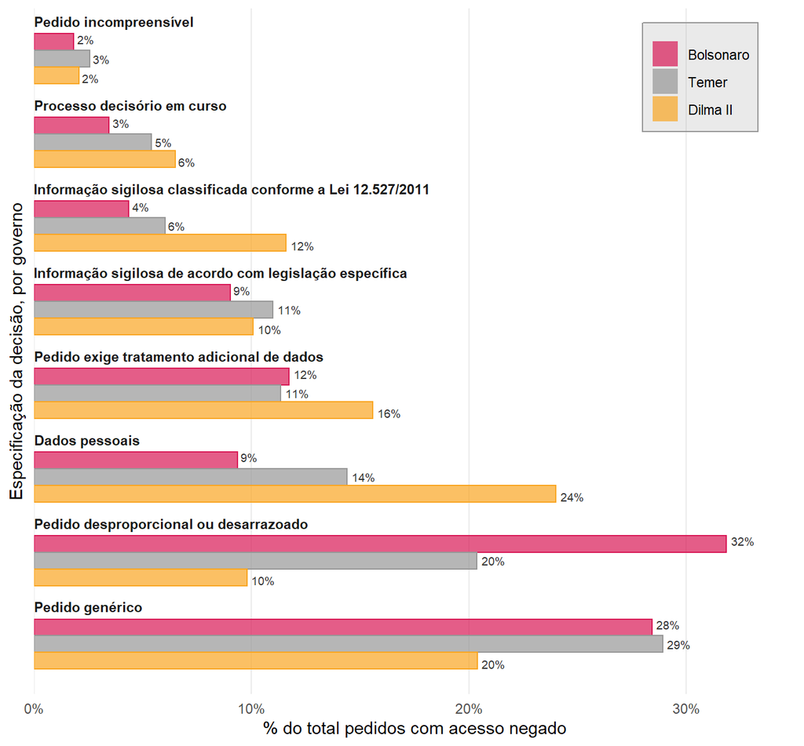

```r
especificacao_decisao_negada <- pedidos_cgu %>%
  select(id_pedido, especificacao_decisao, governo_que_respondeu) %>%
  left_join(controversos, .) %>%
  filter(prevalencia == T) %>%
  group_by(especificacao_decisao, controversos, governo_que_respondeu) %>%
  summarise(qt_especificacao_por_termo_controverso = n(), .groups = "drop") %>%
  group_by(especificacao_decisao, governo_que_respondeu) %>%
  mutate(qt_especificacao_decisao = sum(qt_especificacao_por_termo_controverso)) %>%
  ungroup() %>%
  group_by(governo_que_respondeu) %>%
  mutate(qt_governo_negou = sum(qt_especificacao_por_termo_controverso)) %>%
  ungroup() %>%
  arrange(-qt_governo_negou, -qt_especificacao_decisao, -qt_especificacao_por_termo_controverso) %>%
  mutate(perc = qt_especificacao_por_termo_controverso / qt_especificacao_decisao,
         especificacao_decisao = str_wrap(especificacao_decisao, 45))

especificacao_decisao_negada %>%
  mutate(
    especificacao_decisao = str_replace_all(especificacao_decisao, fixed("\n"), " ")
  ) %>%
  select(
    especificacao_decisao,
    governo_que_respondeu,
    qt_governo_negou,
    qt_especificacao_decisao
  ) %>%
  distinct() %>%
  mutate(perc = qt_especificacao_decisao / qt_governo_negou) %>%
  ggplot(
    aes(
      x = reorder(especificacao_decisao, -perc),
      y = perc,
      fill = governo_que_respondeu,
      color = governo_que_respondeu
    )
  ) +
  geom_bar(position = "dodge", stat = "identity", alpha = .7, width = .6) +
  geom_text(
    aes(label = scales::percent(perc, accuracy = 1, decimal.mark = ",")),
    hjust = -.2,
    check_overlap = T,
    size = 2.5,
    color = "gray20",
    position = position_dodge(width = .7)
  ) +
  geom_text(
    aes(label = reorder(especificacao_decisao, -perc),
        x = reorder(especificacao_decisao, -perc)),
    y = 0,
    color = "gray10",
    check_overlap = T,
    size = 3,
    hjust = 0,
    vjust = -3,
    fontface = "bold"
  ) +
  coord_flip() +
  labs(
    x = "Especificação da decisão, por governo",
    y = "% do total pedidos com acesso negado",
    fill = NULL
  ) +
  theme_minimal() +
  scale_fill_manual(values = paleta_governo) +
  scale_color_manual(values = paleta_governo, guide = FALSE) +
  scale_y_continuous(
    labels = scales::percent_format(decimal.mark = ","),
    expand = c(0 , 0),
    limits = c(0 ,.35)
  ) +
  theme(
    #legend.position = "top",
    legend.justification = "left",
    axis.text.y = element_blank(),
    panel.grid.major.y = element_blank(),
    panel.grid.minor.x = element_blank(),
    legend.direction = "vertical",
    legend.position = c(0.80, 0.9),
    legend.background = element_rect(fill = alpha(aep_colors[["cinza"]], .2), color = aep_colors[["cinza"]])

  ) + guides(fill = guide_legend(reverse = T))
```

#### Especificação das decisões de acesso negado

##### Percentual da justificativa nos pedidos com acesso negados

De janeiro a maio do ano de referência

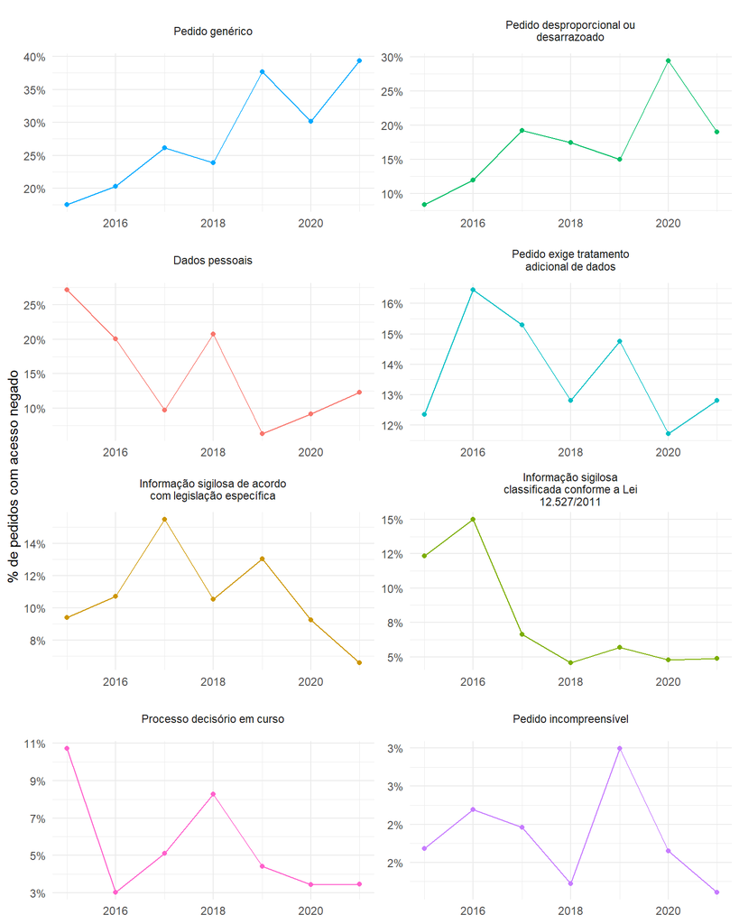

```r
pedidos_cgu %>%
  select(id_pedido, especificacao_decisao, governo_que_respondeu) %>%
  left_join(controversos, .) %>%
  filter(prevalencia == T)  %>%
  transmute(ano = year(data_resposta),
            mes = month(data_resposta),
            dia = day(ts_resposta),
            governo_que_respondeu,
            id_pedido,
            controversos,
            especificacao_decisao = str_wrap(especificacao_decisao, 30)) %>%
  filter(mes < 6) %>%
  group_by(ano, especificacao_decisao) %>%
  summarise(qt_espec = n(), .groups = "drop") %>%
  group_by(ano) %>%
  mutate(perc = qt_espec / sum(qt_espec)) %>%
  ungroup() %>%
  ggplot(aes(x = ano, y = perc, color = especificacao_decisao)) +
  geom_point(show.legend = F) +
  geom_line(show.legend = F) +
  facet_wrap( ~ reorder(especificacao_decisao, -perc), ncol = 2, scales = "free") +
  scale_y_continuous(labels = scales::percent_format(decimal.mark = ",", accuracy = 1)) +
  theme_minimal() +
  labs(
    x = NULL,
    y = "% de pedidos com acesso negado"
  )
```

```r
# Agrupa prevalência de palavras -----------------------------------------------
controversos2 <- controversos %>%
  group_by(data_resposta,
           governo_que_respondeu,
           total_acessos_negados_gov,
           total_acessos_negados_mes,
           controversos,
           prevalencia) %>%
  summarise(qt_prevalencia = n(), .groups = "drop")

# Remove pedidos sem os termos e trata base ------------------------------------
controversos2 <- controversos2 %>%
  filter(prevalencia == TRUE) %>%
  mutate(controversos = case_when(
    controversos == "desarrazoado" ~ "Desarrazoado",
    controversos == "fishing" ~ "Fishing",
    controversos == "desproporcional" ~ "Desproporcional",
    controversos == "seguranca" ~ "Segurança Nacional",
    controversos == "sigilo" ~ "Dados sigilosos",
    controversos == "decisao" ~ "Processo decisório em curso",
    controversos == "trabalho_adic" ~"Trabalho adicional",
    controversos == "dados_pessoais" ~ "Dados pessoais",
    controversos == "generico" ~ "Pedido genérico",
    controversos ==  "lgpd" ~ "LGPD",
    TRUE ~ controversos
  )) %>%
  mutate(controversos = fct_reorder(controversos, prevalencia),
         perc = qt_prevalencia / total_acessos_negados_mes)

# Posso somar a prevalência (ou não-prevalência, se prevalencia==FALSE) de um termo, por governante:
controversos_gov <- controversos2 %>%
  group_by(governo_que_respondeu, controversos, prevalencia) %>%
  summarise(qt_prevalencia_por_gov = sum(qt_prevalencia), .groups = "drop")
```

#### Termos controversos nas negativas de acesso a informação

##### Pedidos classificados com “acesso negado” pelos órgãos do Executivo federal - por mês e por governo

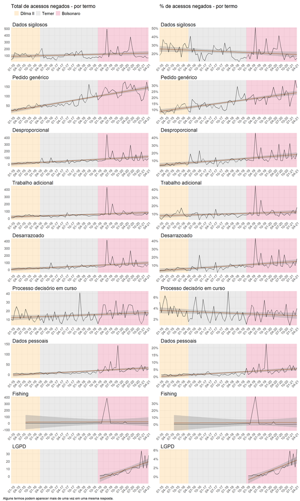

```r
rect_gov <- rect_gov %>% mutate(governo_que_respondeu = fct_reorder(governo_que_respondeu, xmin))
# plot esquerdo ----------------------------------------------------------------
p1 <- controversos2 %>%
  ggplot() +
  geom_rect(
    data = rect_gov,
    aes(xmin = xmin, xmax = xmax, ymin = ymin, ymax = ymax, fill = governo_que_respondeu),
    alpha = .2, show.legend = T
  ) +
  geom_smooth(aes(x = data_resposta, y = qt_prevalencia), method = "lm", color = aep_colors[["marrom"]]) +
  geom_line(aes(x = data_resposta, y = qt_prevalencia)) +
  scale_fill_manual(values = paleta_governo) +
  scale_color_manual(values = paleta_governo) +
  scale_x_date(breaks = scales::date_breaks("3 months"), date_labels = "%m-%y", expand = c(0 ,0)) +
  theme_minimal() +
  theme(
    legend.position = "top",
    legend.justification = "left",
    legend.text = element_text(size = 15),
    axis.text.x = element_text(hjust = .5, vjust = .5, angle = 45, size = 12),
    axis.text.y = element_text(size = 12),
    plot.subtitle = element_text(vjust = 0, hjust = 0, size = 18),
    panel.grid.minor = element_blank(),
    strip.text.x = element_text(size = 18, hjust = 0, vjust = 0)
  ) +
  labs(
    x = NULL,
    y = NULL,
    subtitle = "Total de acessos negados - por termo",
    color = NULL,
    fill = NULL
  ) +
  facet_wrap(~ reorder(controversos, -perc), scales = 'free', ncol = 1)

# plot direita -----------------------------------------------------------------
p2 <- controversos2 %>%
  ggplot() +
  geom_rect(
    data = rect_gov,
    aes(xmin = xmin, xmax = xmax, ymin = ymin, ymax = ymax, fill = governo_que_respondeu),
    alpha = .2, show.legend = F
  ) +
  geom_smooth(aes(x = data_resposta, y = perc), method = "lm", color = aep_colors[["marrom"]]) +
  geom_line(aes(x = data_resposta, y = perc)) +
  scale_fill_manual(values = paleta_governo) +
  scale_color_manual(values = paleta_governo) +
  scale_x_date(breaks = scales::date_breaks("3 months"), date_labels = "%m-%y", expand = c(0 ,0)) +
  scale_y_continuous(labels = scales::percent_format(accuracy = 1, decimal.mark = ","), expand = c(0 ,0)) +
  theme_minimal() +
  theme(
    legend.position = "top",
    legend.text = element_text(size = 15),
    axis.text.x = element_text(hjust = .5, vjust = .5, angle = 45, size = 12),
    axis.text.y = element_text(size = 12),
    plot.title = element_text(vjust = 0, hjust = 0),
    plot.subtitle = element_text(vjust = 0, hjust = 0, size = 18),
    panel.grid.minor = element_blank(),
    strip.text.x = element_text(size = 18, hjust = 0, vjust = 0)
  ) +
  labs(
    x = NULL,
    y = NULL,
    subtitle = "% de acessos negados - por termo",
    color = NULL,
    fill = NULL
  ) +
  facet_wrap(~ reorder(controversos, -perc), scales = 'free', ncol = 1)


comb <- p1 + p2
comb + plot_annotation(
  caption = "Alguns termos podem aparecer mais de uma vez em uma mesma resposta.",
  theme = theme(plot.caption =  element_text(size = 12, hjust = 0, vjust = 0))
)
```

#### Especificação das decisões de acesso negado

##### Justificativa resumida inserida pelos órgãos do Governo Federal

Os quadrantes em cinza significa que não houve detecção de termos no corpo dos pedidos com a especificação da negativa

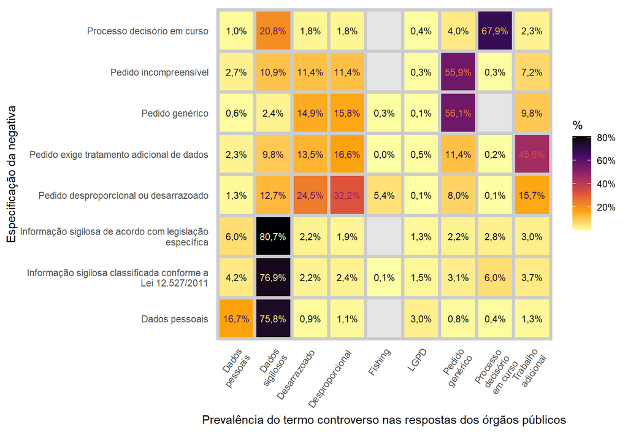

```r
especificacao_decisao_negada %>%
   mutate(controversos = case_when(
    controversos == "desarrazoado" ~ "Desarrazoado",
    controversos == "fishing" ~ "Fishing",
    controversos == "desproporcional" ~ "Desproporcional",
    controversos == "seguranca" ~ "Segurança Nacional",
    controversos == "sigilo" ~ "Dados sigilosos",
    controversos == "decisao" ~ "Processo decisório em curso",
    controversos == "trabalho_adic" ~"Trabalho adicional",
    controversos == "dados_pessoais" ~ "Dados pessoais",
    controversos == "generico" ~ "Pedido genérico",
    controversos ==  "lgpd" ~ "LGPD",
    TRUE ~ controversos
    ) %>% str_wrap(10)
  ) %>%
  group_by(especificacao_decisao, controversos) %>%
  summarise(qt_controverso = sum(qt_especificacao_por_termo_controverso), .groups = "drop") %>%
  group_by(especificacao_decisao) %>%
  mutate(qt_decisao = sum(qt_controverso)) %>% ungroup() %>%
  complete(especificacao_decisao, controversos) %>%
  mutate(perc = qt_controverso / qt_decisao) %>%
  ggplot(aes(x = controversos, y = especificacao_decisao, fill = perc)) +
  geom_tile(color = "gray80", size = 1.5) +
  geom_text(
    aes(label = scales::percent(perc, accuracy = 0.1, decimal.mark = ","), color = perc),
    check_overlap = T,
    size = 3,
    show.legend = F
  ) +
  scale_fill_viridis_c(
    na.value = "gray90",
    direction = -1,
    option = "inferno",
    labels = scales::percent_format(decimal.mark = ",")
  ) +
  scale_color_viridis_c(
    option = "inferno",
    direction = 1,
    na.value = "gray80"
  ) +
  labs(
    y = "Especificação da negativa",
    x = "Prevalência do termo controverso nas respostas dos órgãos públicos",
    fill = "%"
  ) +
  theme_minimal() +
  theme(
    axis.text.x = element_text(angle = 55, hjust = 1.05, vjust = 1.05),
    axis.ticks = element_blank(),
    panel.grid = element_blank()
  )
```

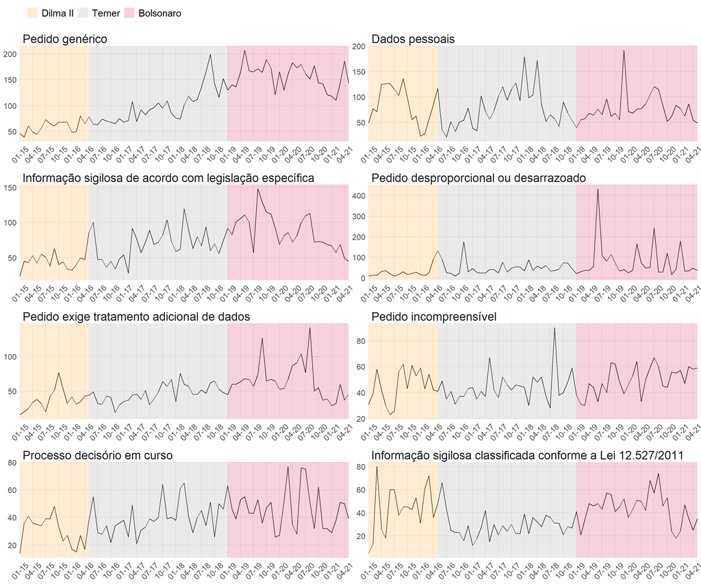

```r
acessos_negados <- pedidos_cgu %>%
  filter(decisao == "Acesso Negado") %>%
  group_by(data_resposta, governo_que_respondeu, especificacao_decisao) %>%
  summarise(qt_especificacao_decisao = n(), .groups = "drop")

acessos_negados %>%
  ggplot() +
  geom_line(aes(x = data_resposta, y = qt_especificacao_decisao)) +
  geom_rect(
    data = rect_gov,
    aes(xmin = xmin, xmax = xmax, ymin = ymin, ymax = ymax, fill = governo_que_respondeu),
    alpha = .2, show.legend = T
  ) +
  scale_fill_manual(values = paleta_governo) +
  scale_color_manual(values = paleta_governo) +
  scale_x_date(breaks = scales::date_breaks("3 months"), date_labels = "%m-%y", expand = c(0 ,0)) +
  theme_minimal() +
  labs(
    fill = NULL,
    x = NULL,
    y = NULL
  ) +
  theme(
    legend.position = "top",
    legend.justification = "left",
    legend.text = element_text(size = 15),
    axis.text.x = element_text(hjust = .5, vjust = .5, angle = 45, size = 12),
    axis.text.y = element_text(size = 12),
    plot.subtitle = element_text(vjust = 0, hjust = 0, size = 18),
    panel.grid.minor = element_blank(),
    strip.text.x = element_text(size = 18, hjust = 0, vjust = 0)
  ) +
  facet_wrap( ~ reorder(especificacao_decisao, -qt_especificacao_decisao), scales = "free", ncol = 2)
```

### Uso da LGPD nas negativas de acesso a informação

```r
library(timetk)
library(sweep)
library(forecast)

# Step 1: Coerce to a ts object class.
ts_controversos_nest <- controversos %>%
  select(data_resposta, id_pedido, controversos, governo_que_respondeu, prevalencia) %>%
  filter(prevalencia) %>%
  complete(data_resposta, controversos, fill = list(prevalencia = 0)) %>%
  group_by(data_resposta, controversos) %>%
  summarise(prevalencia = sum(prevalencia), .groups = "drop") %>%
  group_by(controversos) %>%
  nest() %>%
  ungroup() %>%
  mutate(data_ts = map(data, tk_ts, select = -data_resposta, start = 2015, fre = 12),
         fit_ets = map(data_ts, ets))

# Step 2: Apply a model (or set of models)
# sw_tidy
ts_controversos_nest %>%
  mutate(tidy = map(fit_ets, sw_tidy)) %>%
    unnest(tidy) %>%
    spread(key = controversos, value = estimate)
```

```
#> # A tibble: 88 x 13
#>    data            data_ts     fit_ets term  dados_pessoais decisao desarrazoado
#>    <list>          <list>      <list>  <chr>          <dbl>   <dbl>        <dbl>
#>  1 <tibble [77 x ~ <ts [77 x ~ <ets>   alpha          0.156 NA         NA
#>  2 <tibble [77 x ~ <ts [77 x ~ <ets>   l              4.00  NA         NA
#>  3 <tibble [77 x ~ <ts [77 x ~ <ets>   alpha         NA      0.0976    NA
#>  4 <tibble [77 x ~ <ts [77 x ~ <ets>   l             NA     14.1       NA
#>  5 <tibble [77 x ~ <ts [77 x ~ <ets>   alpha         NA     NA          0.0311
#>  6 <tibble [77 x ~ <ts [77 x ~ <ets>   b             NA     NA          0.495
#>  7 <tibble [77 x ~ <ts [77 x ~ <ets>   beta          NA     NA          0.0310
#>  8 <tibble [77 x ~ <ts [77 x ~ <ets>   gamma         NA     NA          0.000205
#>  9 <tibble [77 x ~ <ts [77 x ~ <ets>   l             NA     NA         12.2
#> 10 <tibble [77 x ~ <ts [77 x ~ <ets>   phi           NA     NA          0.898
#> # ... with 78 more rows, and 6 more variables: desproporcional <dbl>,
#> #   fishing <dbl>, generico <dbl>, lgpd <dbl>, sigilo <dbl>,
#> #   trabalho_adic <dbl>
```

```r
# sw_glance
ts_controversos_nest %>%
    mutate(glance = map(fit_ets, sw_glance)) %>%
    unnest(glance)
```

```
#> # A tibble: 9 x 16
#>   controversos  data      data_ts   fit_ets model.desc  sigma logLik   AIC   BIC
#>   <chr>         <list>    <list>    <list>  <chr>       <dbl>  <dbl> <dbl> <dbl>
#> 1 dados_pessoa~ <tibble ~ <ts [77 ~ <ets>   ETS(A,N,N) 16.9    -384.  774.  781.
#> 2 decisao       <tibble ~ <ts [77 ~ <ets>   ETS(A,N,N)  6.75   -313.  633.  640.
#> 3 desarrazoado  <tibble ~ <ts [77 ~ <ets>   ETS(M,Ad,~  0.696  -410.  856.  898.
#> 4 desproporcio~ <tibble ~ <ts [77 ~ <ets>   ETS(M,Ad,~  0.559  -413.  862.  904.
#> 5 fishing       <tibble ~ <ts [77 ~ <ets>   ETS(A,N,N) 44.3    -458.  922.  929.
#> 6 generico      <tibble ~ <ts [77 ~ <ets>   ETS(M,A,M)  0.199  -365.  764.  804.
#> 7 lgpd          <tibble ~ <ts [77 ~ <ets>   ETS(A,A,N)  3.38   -259.  528.  540.
#> 8 sigilo        <tibble ~ <ts [77 ~ <ets>   ETS(M,N,M)  0.424  -452.  934.  969.
#> 9 trabalho_adic <tibble ~ <ts [77 ~ <ets>   ETS(M,N,M)  0.482  -398.  825.  861.
#> # ... with 7 more variables: ME <dbl>, RMSE <dbl>, MAE <dbl>, MPE <dbl>,
#> #   MAPE <dbl>, MASE <dbl>, ACF1 <dbl>
```

```r
# sw_augment
augment_fit_ets <- ts_controversos_nest %>%
    mutate(augment = map(fit_ets, sw_augment, timetk_idx = TRUE, rename_index = "date")) %>%
    unnest(augment)

# augment_fit_ets %>%
#     ggplot(aes(x = date, y = .resid, group = controversos)) +
#     geom_hline(yintercept = 0, color = "grey40") +
#     geom_line() +
#     geom_smooth(method = "loess", color = aep_colors[["marrom"]]) +
#     labs(title = "Termos controversos nas negativas de acesso a informação",
#          subtitle = "ETS Model Residuals", x = "") +
#     theme_minimal() +
#     facet_wrap(~ controversos, scale = "free_y", ncol = 3) +
#     scale_x_date(date_labels = "%Y")

# sw_tidy_decomp
ts_controversos_nest %>%
    mutate(decomp = map(fit_ets, sw_tidy_decomp, timetk_idx = TRUE, rename_index = "date")) %>%
    unnest(decomp)
```

```
#> # A tibble: 693 x 9
#>    controversos  data    data_ts  fit_ets date       observed level slope season
#>    <chr>         <list>  <list>   <list>  <date>        <dbl> <dbl> <dbl>  <dbl>
#>  1 dados_pessoa~ <tibbl~ <ts [77~ <ets>   2015-01-01        0  3.37    NA     NA
#>  2 dados_pessoa~ <tibbl~ <ts [77~ <ets>   2015-02-01        4  3.47    NA     NA
#>  3 dados_pessoa~ <tibbl~ <ts [77~ <ets>   2015-03-01        5  3.71    NA     NA
#>  4 dados_pessoa~ <tibbl~ <ts [77~ <ets>   2015-04-01        7  4.23    NA     NA
#>  5 dados_pessoa~ <tibbl~ <ts [77~ <ets>   2015-05-01        5  4.35    NA     NA
#>  6 dados_pessoa~ <tibbl~ <ts [77~ <ets>   2015-06-01        2  3.98    NA     NA
#>  7 dados_pessoa~ <tibbl~ <ts [77~ <ets>   2015-07-01        7  4.45    NA     NA
#>  8 dados_pessoa~ <tibbl~ <ts [77~ <ets>   2015-08-01        3  4.22    NA     NA
#>  9 dados_pessoa~ <tibbl~ <ts [77~ <ets>   2015-09-01        0  3.56    NA     NA
#> 10 dados_pessoa~ <tibbl~ <ts [77~ <ets>   2015-10-01        2  3.32    NA     NA
#> # ... with 683 more rows
```

```r
# Step 3: Forecast the models (similar to predict)
ts_controversos_fcast <- ts_controversos_nest %>%
    mutate(fcast_ets = map(fit_ets, forecast, h = 12))
ts_controversos_fcast
```

```
#> # A tibble: 9 x 5
#>   controversos    data              data_ts       fit_ets fcast_ets
#>   <chr>           <list>            <list>        <list>  <list>
#> 1 dados_pessoais  <tibble [77 x 2]> <ts [77 x 1]> <ets>   <forecast>
#> 2 decisao         <tibble [77 x 2]> <ts [77 x 1]> <ets>   <forecast>
#> 3 desarrazoado    <tibble [77 x 2]> <ts [77 x 1]> <ets>   <forecast>
#> 4 desproporcional <tibble [77 x 2]> <ts [77 x 1]> <ets>   <forecast>
#> 5 fishing         <tibble [77 x 2]> <ts [77 x 1]> <ets>   <forecast>
#> 6 generico        <tibble [77 x 2]> <ts [77 x 1]> <ets>   <forecast>
#> 7 lgpd            <tibble [77 x 2]> <ts [77 x 1]> <ets>   <forecast>
#> 8 sigilo          <tibble [77 x 2]> <ts [77 x 1]> <ets>   <forecast>
#> 9 trabalho_adic   <tibble [77 x 2]> <ts [77 x 1]> <ets>   <forecast>
```

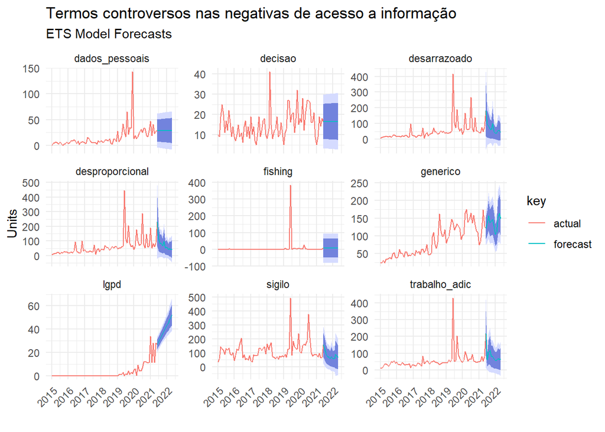

```r
# Step 4: Tidy the forecast
ts_controversos_fcast_tidy <- ts_controversos_fcast %>%
    mutate(sweep = map(fcast_ets, sw_sweep, fitted = FALSE, timetk_idx = TRUE)) %>%
    unnest(sweep)

ts_controversos_fcast_tidy %>%
    ggplot(aes(x = index, y = prevalencia, color = key, group = controversos)) +
    geom_ribbon(aes(ymin = lo.95, ymax = hi.95),
                fill = "#D5DBFF", color = NA, size = 0) +
    geom_ribbon(aes(ymin = lo.80, ymax = hi.80, fill = key),
                fill = "#596DD5", color = NA, size = 0, alpha = 0.8) +
    geom_line() +
    labs(title = "Termos controversos nas negativas de acesso a informação",
         subtitle = "ETS Model Forecasts",
         x = "", y = "Units") +
    scale_x_date(date_breaks = "1 year", date_labels = "%Y") +
  # scale_fill_manual(values = paleta_governo) +
  # scale_color_manual(values = paleta_governo) +
    facet_wrap(~ controversos, scales = "free_y", ncol = 3) +
    theme_minimal() +
    theme(axis.text.x = element_text(angle = 45, hjust = 1))
```

```r
kableExtra::kbl(
  pedidos_cgu %>% distinct(especificacao_decisao)
) %>% kableExtra::kable_paper()
```

| especificacao_decisao |
| --- |
| Resposta solicitada inserida no Fala.Br |
| Informação sigilosa classificada conforme a Lei 12.527/2011 |
| Orientação sobre como encontrar a informação solicitada na Internet ou em publicações existentes |
| Informações enviadas por e-mail |
| Pedido incompreensível |
| Pedido genérico |
| Parte da informação é sigilosa de acordo com legislação específica |
| Informação sigilosa de acordo com legislação específica |
| Parte da informação é sigilosa e classificada conforme a Lei 12.527/2011 |
| Dados pessoais |
| Parte da informação é de competência de outro órgão/entidade |
| Processo decisório em curso |
| Parte da informação contém dados pessoais |
| Parte da informação inexistente |
| Concedido acesso a sistema corporativo para consulta da informação |
| Pedido desproporcional ou desarrazoado |
| Parte da informação demandará mais tempo para produção |
| Data, hora e local para consulta agendados |
| Pedido exige tratamento adicional de dados |
| Parte do pedido é desproporcional ou desarrazoado |
| Comunicada necessidade de pagamento de custos de postagem e/ou reprodução |
| Parte do pedido é genérico |
| Parte do pedido é incompreensível |
| Informações enviadas pelo correio |